# Zappos Website Data Analysis

#### Inference

- This shows that for the sites Botly, Tabular and Widgetry, not all platforms are being used.
- Windows is the most used platform for bth Acme and Pinnacle, whereas, iOS is popular for Sortly, Tabular and Widgetry
3. **Site vs Bounces - This will help us analyze the sites which are unattractive (highes bounces).**

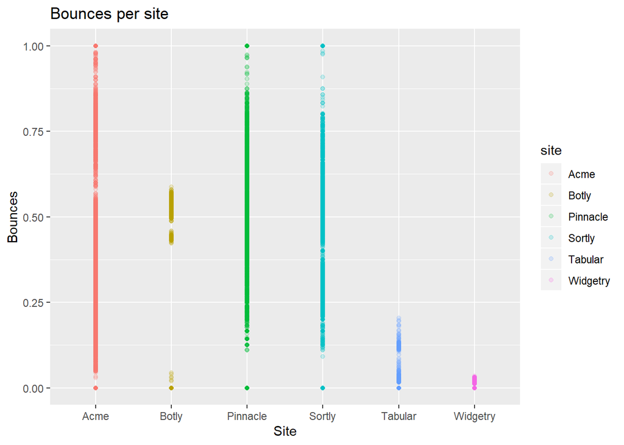

```r
library(dplyr)
library(ggplot2)

siteVisitsDF %>%
  mutate(bounce_rate = bounces/visits) %>%
  ggplot(aes(y=bounce_rate, x= site)) +
  geom_point(aes(color = site), alpha = .2) +
  labs(title = "Bounces per site",
       x = "Site",
       y = "Bounces")
```

Considering, that the scatter plot shows the data all over the place, let us try to visualize this through a box plot to compare each site and corresponding bounces.

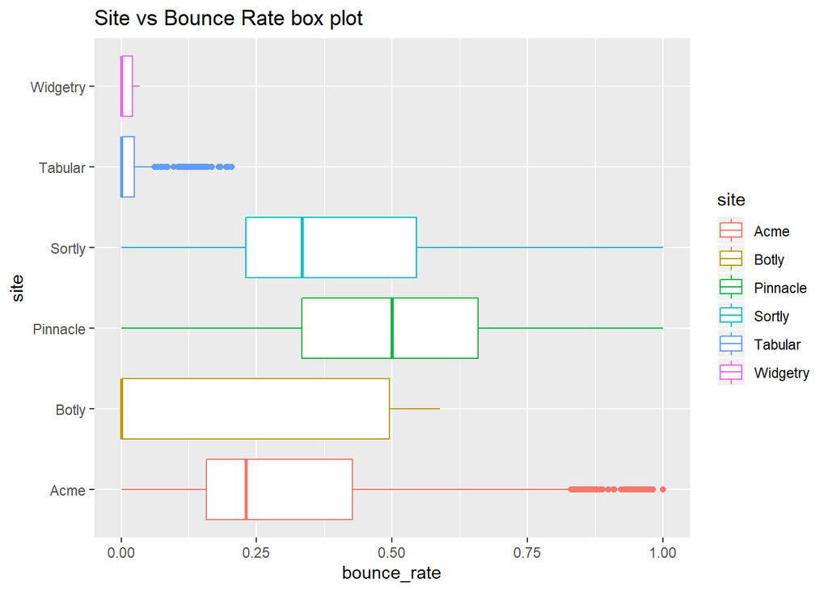

```r
library(dplyr)
library(ggplot2)

siteVisitsDF %>%
  mutate(bounce_rate = bounces/visits) %>%
  ggplot(aes(y=bounce_rate, x= site)) +
  geom_boxplot(aes(color = site)) +
  coord_flip() +
  labs (title = "Site vs Bounce Rate box plot")
```

#### Inference

- This shows that the sites Pinnacle and Sortly have the highes bounce rate. Thus, this proves these sites are the least attractive.
4. **Site vs Conversion Rate - This will help us analyze the sites which have the highest conversion ratio.**

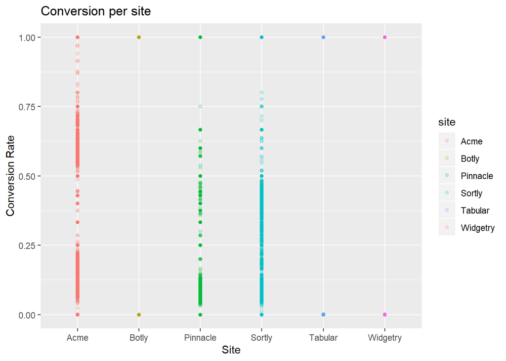

```r
library(dplyr)
library(ggplot2)

siteVisitsDF %>%
  mutate(conversion_rate = orders/visits) %>%
  ggplot(aes(y=conversion_rate, x= site)) +
  geom_point(aes(color = site), alpha = .2) +
  labs(title = "Conversion per site",
       x = "Site",
       y = "Conversion Rate")
```

Considering, that the scatter plot shows the data all over the place, let us try to visualize this through a box plot to compare each site and corresponding conversions.

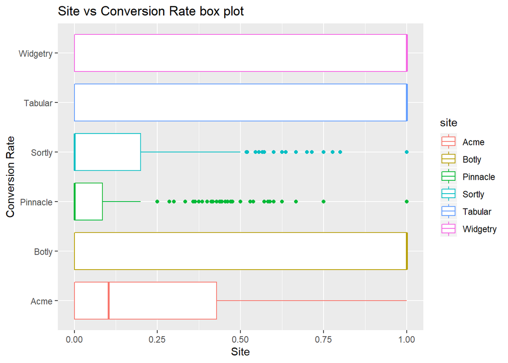

```r
library(dplyr)
library(ggplot2)

siteVisitsDF %>%
  mutate(conversion_rate = orders/visits) %>%
  ggplot(aes(y=conversion_rate, x= site)) +
  geom_boxplot(aes(color = site)) +
  coord_flip() +
  labs (title = "Site vs Conversion Rate box plot",
       y = "Site",
       x = "Conversion Rate")
```

#### Inference

- This shows that the median conversion rate in the sites Widgetry, Tabular and Botly are close to 1. So, once an user enters in one of these sites, the chances of placing an order is pretty high.
5. **Platform vs Add to Cart Rate - This will help us analyze which platforms have the highest add to cart rate.**

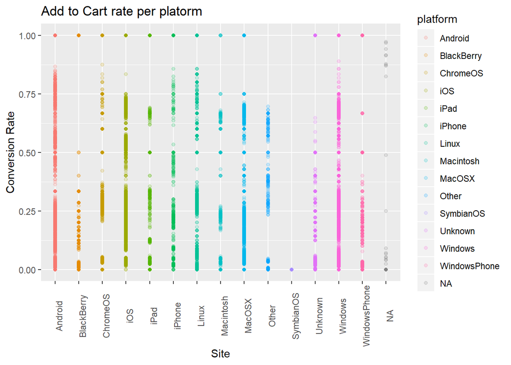

```r
library(dplyr)
library(ggplot2)

siteVisitsDF %>%
  mutate(add_to_cart_rate = add_to_cart/visits) %>%
  ggplot(aes(y=add_to_cart_rate, x= platform)) +
  geom_point(aes(color = platform), alpha = .2) +
  labs(title = "Add to Cart rate per platorm",
       x = "Site",
       y = "Conversion Rate") +
  theme(legend.direction = "vertical", axis.text.x = element_text(angle = 90))
```

Considering, that the scatter plot shows the data all over the place, let us try to visualize this through a box plot to compare each site and corresponding conversions.

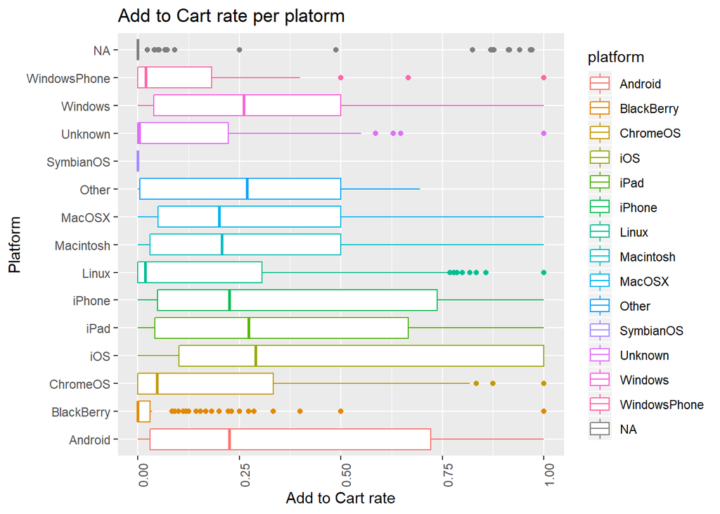

```r
library(dplyr)
library(ggplot2)

siteVisitsDF %>%
  mutate(add_to_cart_rate = add_to_cart/visits) %>%
  ggplot(aes(y=add_to_cart_rate, x= platform)) +
  geom_boxplot(aes(color = platform)) +
  coord_flip() +
  labs(title = "Add to Cart rate per platorm",
       x = "Platform",
       y = "Add to Cart rate") +
  theme(legend.direction = "vertical", axis.text.x = element_text(angle = 90))
```

#### Inference

- This shows that the highest median add to cart rate is on iOS. So, this gives us an impression that the iOS application is really effective.

**Finally, let us do a Multivariate analysis between Site, Platform vs Conversion Rate - This will really help us draw the conclusion of which site, platform combination gives the best Conversion.**

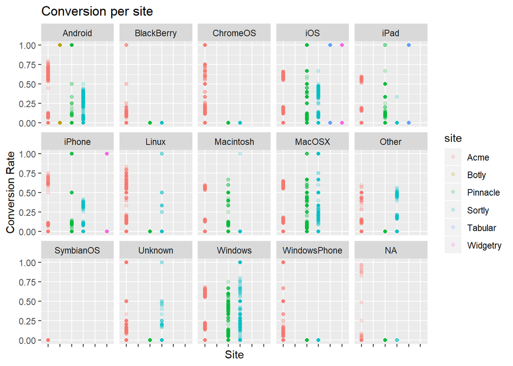

```r
library(dplyr)
library(ggplot2)

siteVisitsDF %>%
  mutate(conversion_rate = orders/visits) %>%
  ggplot(aes(y=conversion_rate, x= site)) +
  geom_point(aes(color = site), alpha = .2) +
  facet_wrap(~ platform, nrow = 3, ncol = 5) +
  labs(title = "Conversion per site",
       x = "Site",
       y = "Conversion Rate") +
    theme(axis.text.x = element_blank())
```

To understand this better, let us plot the box and whisker plots.

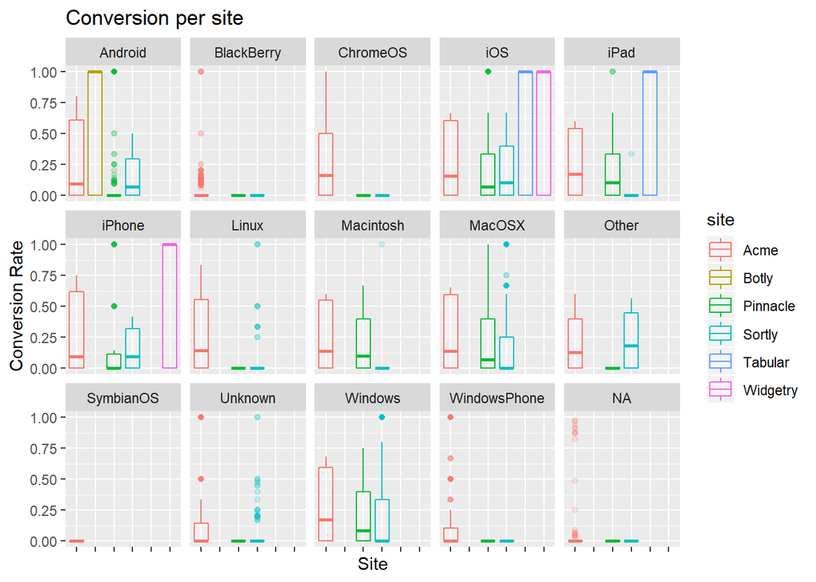

```r
library(dplyr)
library(ggplot2)

siteVisitsDF %>%
  mutate(conversion_rate = orders/visits) %>%
  ggplot(aes(y=conversion_rate, x= site)) +
  geom_boxplot(aes(color = site), alpha = .2) +
  facet_wrap(~ platform, nrow = 3, ncol = 5) +
  labs(title = "Conversion per site",
       x = "Site",
       y = "Conversion Rate") +
    theme(axis.text.x = element_blank())
```

#### Inference

- This helps us infer the following:
  - For “Acme” the highest median conversion rate is on iOS and Windows
  - For “Botly”, the highest median conversion rate is on Android. Going by the dat, it seems they do not either have any application on any other platform or the data is missing.
  - For “Pinnacle”, the highest median conversion rate is for iPad
  - “Sortly” has the highest median conversion rate in Other platforms
  - iOS and iPad both seem to have 100% median conversion rate for “Tabular”
  - Finally, “Widgetry” has again 100% median conversion rate on iOS and iPhone
- The above list helps us understand, which applications/ sites to be upgraded